# Epi3 HW4

Emilie Bruzelius (eb2674)

June 9, 2015

### P8400 APPLIED DATA ANALYSIS IN EPIDEMIOLOGY

### HOMEWORK 4

INSTRUCTIONS: 1. Please keep your answers brief (1-2 sentences). 2. Please provide relevant SAS codes for your answers.

http://rpubs.com/embruze/85672

#### Part A

Dataset to be used: LiverCa.sas7bdat

For part A, the objective is to analyze which variable forms (continuous, dichotomous, or categorical) of age and alcohol use best describe the measures’ relationships with liver cancer in the following case-control study:

Data dictionary for LiverCa dataset Variable Name Description CaseCont 1=Case (liver cancer) 0=Control Age Age in years (range = 21-91 years) EtOH Daily alcohol consumption: 0=0-9 grams/day 1=10-19 grams/day 2=20-29 grams/day 3=30-39 grams/day 4=40+ grams/day

1. Set up a logistic regression model to examine the effects of the following indicator (dummy) variables of age using ‘21-30’ as the reference group. Report the parameter estimates.

```r
rm(list=ls())
library(sas7bdat)
hw4 <- read.sas7bdat("LiverCa.sas7bdat", debug=FALSE)
head (hw4$age)
```

```
## [1] 21 21 25 25 25 25
```

```r
hw4$age <- as.integer(hw4$age)
sapply(hw4, is.numeric)
```

```
##      age casecont     etoh
##     TRUE     TRUE     TRUE
```

Indicator variable coding

```r
hw4$age.c[hw4$age <= 30] <- "age0"
hw4$age.c[hw4$age >= 31 & hw4$age <= 40] <- "age1"
hw4$age.c[hw4$age >= 41 & hw4$age <= 50] <- "age2"
hw4$age.c[hw4$age >= 51 & hw4$age <= 60] <- "age3"
hw4$age.c[hw4$age >= 61 & hw4$age <= 70] <- "age4"
hw4$age.c[hw4$age >= 71] <- "age5"
hw4$age.f = factor(hw4$age.c, labels=c("age0", "age1", "age2", "age3", "age4", "age5"))
contr.treatment(6)
```

```
##   2 3 4 5 6
## 1 0 0 0 0 0
## 2 1 0 0 0 0
## 3 0 1 0 0 0
## 4 0 0 1 0 0
## 5 0 0 0 1 0
## 6 0 0 0 0 1
```

```r
contrasts(hw4$age.f) = contr.treatment(6)
glm.1 = glm(cbind(casecont) ~ age.f,
              family=binomial(logit), hw4)
summary(glm.1)
```

```
##
## Call:
## glm(formula = cbind(casecont) ~ age.f, family = binomial(logit),
##     data = hw4)
##
## Deviance Residuals:
##     Min       1Q   Median       3Q      Max
## -1.0525  -0.9113  -0.3381  -0.3099   2.4740
##
## Coefficients:
##             Estimate Std. Error z value Pr(>|z|)
## (Intercept)  -3.0123     0.5913  -5.094 3.50e-07 ***
## age.f2        0.1157     0.6833   0.169 0.865500
## age.f3        0.1790     0.6617   0.271 0.786720
## age.f4        2.3481     0.6093   3.853 0.000116 ***
## age.f5        2.4391     0.6069   4.019 5.84e-05 ***
## age.f6        2.7112     0.6298   4.305 1.67e-05 ***
## ---
## Signif. codes:  0 '***' 0.001 '**' 0.01 '*' 0.05 '.' 0.1 ' ' 1
##
## (Dispersion parameter for binomial family taken to be 1)
##
##     Null deviance: 1030.23  on 977  degrees of freedom
## Residual deviance:  874.88  on 972  degrees of freedom
## AIC: 886.88
##
## Number of Fisher Scoring iterations: 5
```

**Parameter estimates:**

- 31-40: 0.1157
- 41-50: 0.1790
- 51-60: 2.3481
- 61-70: 2.4391
- 70 or older: 2.7112

#### 2a.

Plot a graph showing the relationship between the log odds of disease and the six categories of age. Show your graph.

(I’m not sure that this is exactly what your asking for but here goes…)

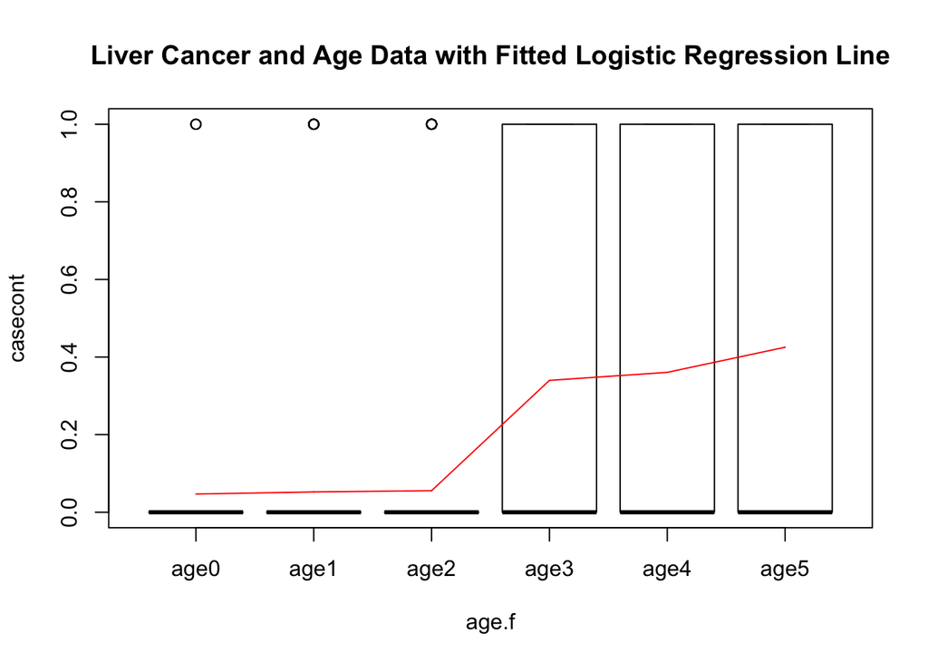

```r
plot(casecont ~ age.f, hw4)
lines(hw4$age.f, glm.1$fitted, type="l", col="red")
title(main="Liver Cancer and Age Data with Fitted Logistic Regression Line")
```

#### 2b.

Based on the above analyses, which variable type for age (continuous, dichotomous or categorical) will you choose? Why?

**In this case I assume you should choose a dichotomous because there seems like there is some sort of age threshold.**

Regardless of what you decided about the variable type for age, let’s examine the effect of the continuous measurement of age (i.e., ‘age’) on liver cancer using logistic regression.

#### 3.

Report the parameter estimate (b), OR and 95% CI for the crude association between ‘age’ and liver cancer. Interpret the results.

```r
exp(cbind(OR = coef(glm.1), confint(glm.1)))
```

```
##                      OR      2.5 %     97.5 %
## (Intercept)  0.04918033 0.01200935  0.1325661
## age.f2       1.12269937 0.32270085  5.1843453
## age.f3       1.19607841 0.36574498  5.3721384
## age.f4      10.46568610 3.70196622 43.9074230
## age.f5      11.46308706 4.08149942 47.9318384
## age.f6      15.04666642 5.05230014 64.9204097
```

#### 4.

Estimate the odds of getting liver cancer for a man aged 65 years with a man who is similar in other respects but aged 45 years.

```r
library(aod)
summary(glm.1)
```

```
##
## Call:
## glm(formula = cbind(casecont) ~ age.f, family = binomial(logit),
##     data = hw4)
##
## Deviance Residuals:
##     Min       1Q   Median       3Q      Max
## -1.0525  -0.9113  -0.3381  -0.3099   2.4740
##
## Coefficients:
##             Estimate Std. Error z value Pr(>|z|)
## (Intercept)  -3.0123     0.5913  -5.094 3.50e-07 ***
## age.f2        0.1157     0.6833   0.169 0.865500
## age.f3        0.1790     0.6617   0.271 0.786720
## age.f4        2.3481     0.6093   3.853 0.000116 ***
## age.f5        2.4391     0.6069   4.019 5.84e-05 ***
## age.f6        2.7112     0.6298   4.305 1.67e-05 ***
## ---
## Signif. codes:  0 '***' 0.001 '**' 0.01 '*' 0.05 '.' 0.1 ' ' 1
##
## (Dispersion parameter for binomial family taken to be 1)
##
##     Null deviance: 1030.23  on 977  degrees of freedom
## Residual deviance:  874.88  on 972  degrees of freedom
## AIC: 886.88
##
## Number of Fisher Scoring iterations: 5
```

```r
l <- cbind(0, 0, 1, 0, -1, 0)
wald.test(b = coef(glm.1), Sigma = vcov(glm.1), L = l)
```

```
## Wald test:
## ----------
##
## Chi-squared test:
## X2 = 47.8, df = 1, P(> X2) = 4.7e-12
```

#### 4b.

For the above question, what is the assumption if we choose to keep age as a continuous variable?

**Keeping age as continuous variable assumes that the relationship is linear on the log-odds scale.**

#### 5.

We will now examine the association between alcohol consumption and liver cancer.

Create indicator variables for the five categories of alcohol use. Use logistic regression to model the effects of indicator variables of alcohol using non-users as the reference group. Report the parameter estimates.

```r
hw4$etoh <- factor(hw4$etoh)
glm.3 <- glm(casecont ~ etoh, hw4, family = "binomial")
summary(glm.3)
```

```
##
## Call:
## glm(formula = casecont ~ etoh, family = "binomial", data = hw4)
##
## Deviance Residuals:
##     Min       1Q   Median       3Q      Max
## -1.0108  -0.7262  -0.6715  -0.5473   1.9862
##
## Coefficients:
##             Estimate Std. Error z value Pr(>|z|)
## (Intercept)  -1.8228     0.1772 -10.288  < 2e-16 ***
## etoh1         0.4479     0.2244   1.996 0.045963 *
## etoh2         0.6246     0.2619   2.385 0.017087 *
## etoh3         1.0433     0.2352   4.436 9.15e-06 ***
## etoh4         1.4173     0.3682   3.850 0.000118 ***
## ---
## Signif. codes:  0 '***' 0.001 '**' 0.01 '*' 0.05 '.' 0.1 ' ' 1
##
## (Dispersion parameter for binomial family taken to be 1)
##
##     Null deviance: 1030.2  on 977  degrees of freedom
## Residual deviance: 1002.4  on 973  degrees of freedom
## AIC: 1012.4
##
## Number of Fisher Scoring iterations: 4
```

**Parameter estimates:** etoh0(Intercept): -1.8228  
etoh1: 0.4479  
etoh2: 0.6246  
etoh3: 1.0433  
etoh4: 1.4173

#### 6.

Plot a graph showing the relationship between the log odds of disease (betas) and the five categories of alcohol use. Show your graph.

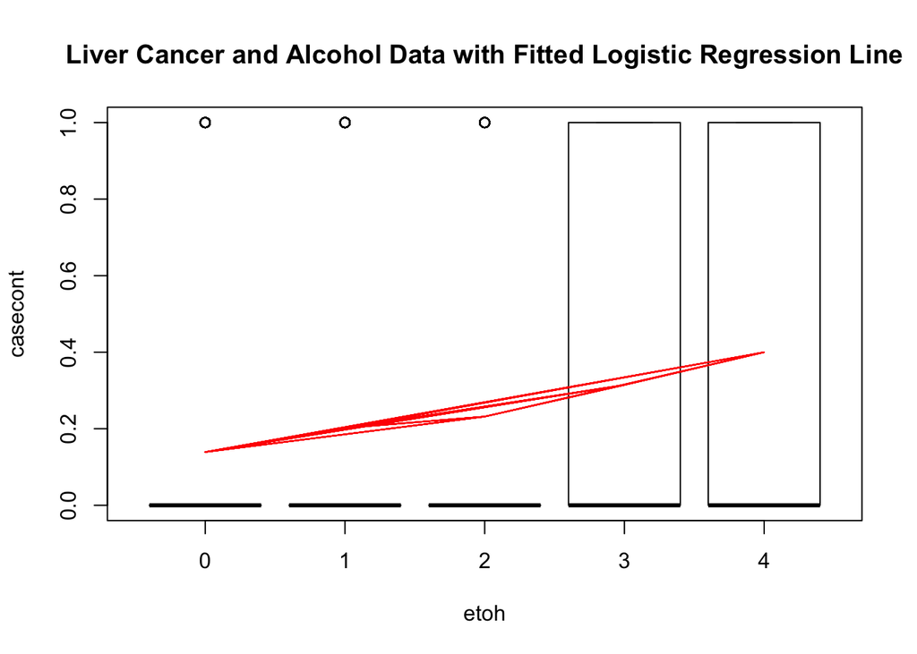

```r
plot(casecont ~ etoh, hw4)
lines(hw4$etoh, glm.3$fitted, type="l", col="red")
title(main="Liver Cancer and Alcohol Data with Fitted Logistic Regression Line")
```

#### 7a.

Do you see a dose-response relationship between alcohol consumption and liver cancer?

**In this data there appears to be a dose-response relationship between alcohol use and liver cancer.**

#### 7b.

Based on the above analyses, which variable type for alcohol (continuous, dichotomous, or categorical) would you choose? Why?

**In this case I would probably keep the variable categorical. If you dichotomize it you’re loosing the dose-response effect. I think it would be hard for people to remember exactly how much alcohol they consume on average a day exactly, but could probably put themselves in an appropriate category.**

#### Part B

Questions for part B are based on the following article:

Calis JC, Phiri KS, Faragher EB, Brabin BJ, Bates I, Cuevas LE, de Haan RJ, Phiri AI, Malange P, Khoka M, Hulshof PJ, van Lieshout L, Beld MG, Teo YY, Rockett KA, Richardson A, Kwiatkowski DP, Molyneux ME, van Hensbroek MB. Severe Anemia in Malawian Children. N Engl J Med. 2008 Feb 28;358(9):888-99.

#### 8.

Using data from Table-2, calculate the overall crude OR for the association between vitamin A deficiency and severe anemia for all study sites combined. Compare this with the adjusted estimate in Figure-1. Is there evidence for confounding of this association based on the 10% change in parameter estimate criteria? If so, in what direction?

**Odds Ratios** (228x90)/(172x19)=6.2791 vs.2.8 (1.3–5.8)

**10% Rule** (6.2791-2.8)/6.2791 = 0.5540 > 10%

**Yes, there is evidence for confounding. The confounding is biasing the estimate away from the null.**

#### 9.

In figure 1, for exposure ‘vitamin A deficiency’, is there effect modification of the association by the variable for study site (rural/urban)? On what scale are the authors assessing this interaction?

Urban: (115x37)/(68x6)=10.4289 Rural: (113x53)/(104x13)=4.4297

10.4289/4.4297= 2.3543>1 **There is evidence of multiplicative interaction.**

For vitamin A, is there evidence to suggest that the two control groups (community/hospital) should be combined for a binary logistic regression or should they be kept separate (as either 2 separate binary logistic regression models or one unordered polytomous model)?

**In this case it probably makes sense to keep them separate. The ORs are not similar - unordered polytomous logistic regression would be appropriate.**

Based on your model, which odds ratios would you report that would best describe the association between vitamin A deficiency and severe anemia?

**I would report the crude ORs and adjusted ORs.**

#### 10.

In figure 1, for exposure ‘HIV’, is there effect modification of the association by the variable for study site (rural/urban)? On what scale are the authors assessing this interaction?

Rural community: 0.5 Rural hospital: 0.3 Urban community: 3.7 Urban hospital 2.2

3.7/0.5 = 7.4 > 1 2.2/0.3 = 7.3 > 1

**There is evidence of multiplicative interaction.**

For HIV, is there evidence to suggest that the two control groups (community/hospital) should be combined for a binary logistic regression or should they be kept separate (as either 2 separate binary logistic regression models or one unordered polytomous model)?

**The ORs are not similar so unordered polytomous logistic regression would be appropriate.**

Based on your model, which odds ratios would you report that would best describe the association between HIV and severe anemia?

**Again, I would report the crude and adjusted ORs.**